# Shocks explore

Dan Killian

10/28/2021

# 1 Introduction

The South Sudan Monitoring and Evaluation Support Project (MESP) is conducting a household resilience survey in 13 counties. The purpose of this household survey is to obtain baseline data in the target areas for the indicators included in the Mission’s Performance Management Plan (PMP) and the Community Roadmap, in support of USAID/South Sudan’s Strategic Framework (2020-2024).

# 2 Shocks and stressers

## 2.1 Overall incidence of shocks

Unweighted

```r
# shck_mn <- dat %>%
#   select(shock_flood:shock_death) %>%
#   summarize_all(mean, na.rm=T) %>%
#   t() %>%
#   as.data.frame() %>%
#   rownames_to_column() %>%
#   set_names(nm=c("var_name","freq")) %>%
#   left_join(shock_key) %>%
#   select(1,3,4,2) %>%
#   arrange(desc(freq))
#
# shck_mn

shck_mn_se <- dat %>%
  select(shock_flood:shock_death) %>%
  summarize(across(everything(),
                   list(mn = ~mean(.,na.rm=T), se = ~std.error(.,na.rm=T)))) %>%
#                   .names="{.col}.{.fn}")) %>% # name the separator from summarize
  pivot_longer(cols=1:32,
               names_to=c("discard", "var_name","measure"),
               names_sep="_",
               values_to="value") %>%
  select(-1) %>%
  pivot_wider(names_from=measure,
              values_from=value) %>%
  mutate(lower=mn-1.96*se,
         upper=mn+1.96*se,
         shock_lab=shock_labs,
         shock=1:16) %>%
  select(1,7,6, 2:5) %>%
  mutate(overall_rank = rank(-mn)) %>%
  arrange(desc(mn))

#write_csv(shck_mn_se, here("output/tables/shocks/shock incidence overall, unweighted.csv"))

shck_mn_se
```

Table 2.1:

| var_name | shock | shock_lab | mn | se | lower | upper | overall_rank |
| --- | --- | --- | --- | --- | --- | --- | --- |
| foodprice | 5 | Increase in food prices | 0.836 | 0.00457 | 0.827 | 0.845 | 1 |
| flood | 1 | Floods | 0.784 | 0.00508 | 0.774 | 0.794 | 2 |
| nosell | 14 | Unable to sell | 0.68 | 0.00767 | 0.665 | 0.695 | 3 |
| erosion | 3 | Erosion | 0.594 | 0.00606 | 0.582 | 0.606 | 4 |
| lostland | 4 | Loss of land | 0.547 | 0.00614 | 0.535 | 0.559 | 5 |
| illness | 15 | Illness in household | 0.523 | 0.00822 | 0.506 | 0.539 | 6 |
| drought | 2 | Drought | 0.492 | 0.00617 | 0.48 | 0.504 | 7 |
| livestockdisease | 12 | Livestock disease | 0.439 | 0.00613 | 0.427 | 0.451 | 8 |
| theft | 6 | Theft | 0.413 | 0.00608 | 0.401 | 0.425 | 9 |
| livestockinputs | 11 | No livestock inputs | 0.385 | 0.00601 | 0.374 | 0.397 | 10 |
| cropdisease | 8 | Crop disease | 0.346 | 0.00587 | 0.334 | 0.357 | 11 |
| croppests | 9 | Crop pests | 0.341 | 0.00585 | 0.33 | 0.353 | 12 |
| cropinputs | 7 | No crop inputs | 0.341 | 0.00585 | 0.329 | 0.352 | 13 |
| livestocktheft | 13 | Livestock theft | 0.332 | 0.00581 | 0.321 | 0.344 | 14 |
| death | 16 | Death in household | 0.305 | 0.00758 | 0.29 | 0.32 | 15 |
| croptheft | 10 | Crop theft | 0.189 | 0.00483 | 0.18 | 0.199 | 16 |

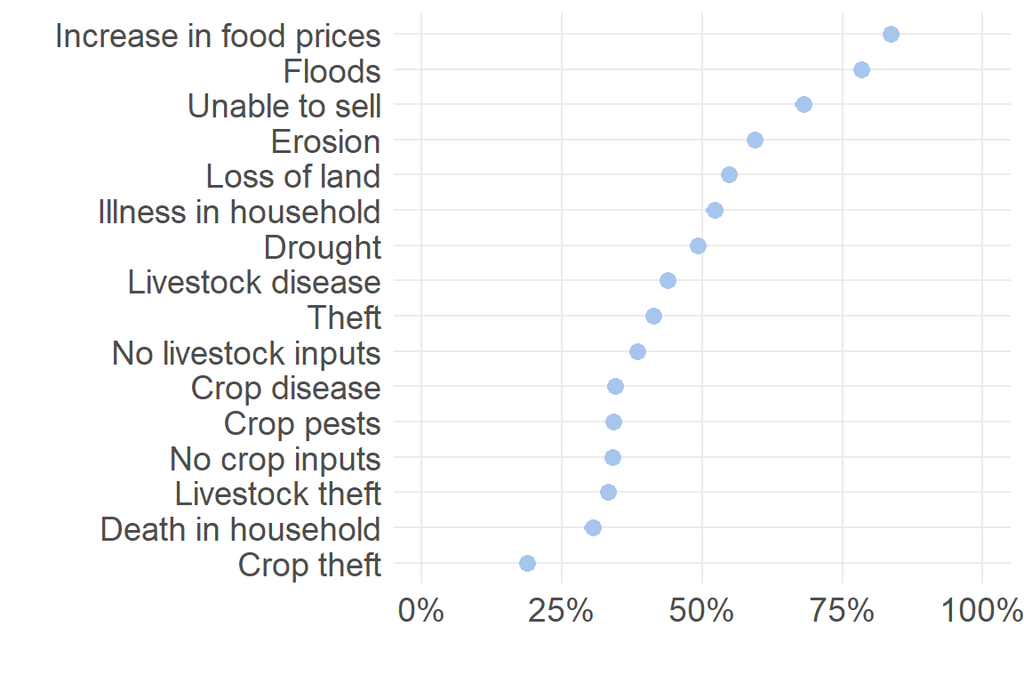

```r
ggplot(shck_mn_se, aes(x=mn, y=fct_reorder(shock_lab, mn))) +
  geom_errorbar(aes(xmin=lower, xmax=upper), width=0, size=1, color=light_blue) +
  geom_point(size=3, color=light_blue) +
  labs(x="",
       y="") +
  scale_x_continuous(labels=percent,
                     limits=c(0,1))
```

Weighted

```r
shck_svy <- svyrdat %>%
  select(shock_flood:shock_death) %>%
  summarize_all(survey_mean, na.rm=T) %>%
  t() %>%
  as.data.frame() %>%
  rownames_to_column() %>%
  set_names(nm=c("var_name","freq"))

shck_mn_svy <- shck_svy %>%
  filter(row_number() %% 2 ==1) %>%
  rename(mn=freq) %>%
  mutate(shock_lab=shock_labs)

shck_se_svy <- shck_svy %>%
  filter(row_number() %% 2 == 0) %>%
  rename(se=freq) %>%
  mutate(shock_lab=shock_labs) %>%
  select(-1)

shck_mn_se_svy <- shck_mn_svy %>%
  left_join(shck_se_svy) %>%
  mutate(lower=mn-1.96*se,
         upper=mn+1.96*se) %>%
  select(1,3,2,4:6)

shck_mn_se_svy
```

Table 2.2:

| var_name | shock_lab | mn | se | lower | upper |
| --- | --- | --- | --- | --- | --- |
| shock_flood | Floods | 0.85 | 0.0188 | 0.813 | 0.886 |
| shock_drought | Drought | 0.484 | 0.0275 | 0.43 | 0.538 |
| shock_erosion | Erosion | 0.534 | 0.0261 | 0.483 | 0.585 |
| shock_lostland | Loss of land | 0.466 | 0.0259 | 0.415 | 0.516 |
| shock_foodprice | Increase in food prices | 0.867 | 0.0127 | 0.842 | 0.892 |
| shock_theft | Theft | 0.512 | 0.0214 | 0.47 | 0.554 |
| shock_cropinputs | No crop inputs | 0.421 | 0.0195 | 0.383 | 0.46 |
| shock_cropdisease | Crop disease | 0.405 | 0.0197 | 0.366 | 0.444 |
| shock_croppests | Crop pests | 0.381 | 0.0198 | 0.343 | 0.42 |
| shock_croptheft | Crop theft | 0.261 | 0.0182 | 0.225 | 0.297 |
| shock_livestockinputs | No livestock inputs | 0.548 | 0.0225 | 0.504 | 0.592 |
| shock_livestockdisease | Livestock disease | 0.591 | 0.0226 | 0.547 | 0.635 |
| shock_livestocktheft | Livestock theft | 0.507 | 0.0245 | 0.459 | 0.555 |
| shock_nosell | Unable to sell | 0.768 | 0.0209 | 0.727 | 0.809 |
| shock_illness | Illness in household | 0.639 | 0.0247 | 0.59 | 0.687 |
| shock_death | Death in household | 0.365 | 0.0253 | 0.316 | 0.415 |

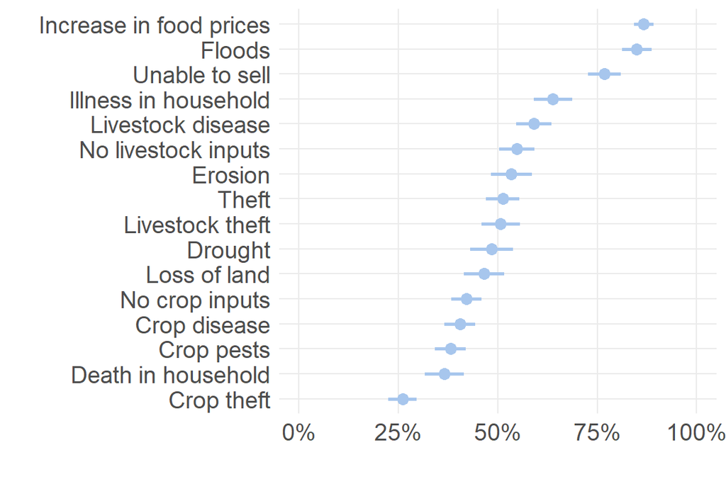

```r
ggplot(shck_mn_se_svy, aes(x=mn, y=fct_reorder(shock_lab, mn))) +
  geom_errorbar(aes(xmin=lower, xmax=upper), width=0, size=1, color=light_blue) +
  geom_point(size=3, color=light_blue) +
  labs(x="",
       y="") +
  scale_x_continuous(labels=percent,
                     limits=c(0,1))
```

## 2.2 Incidence of shocks, by state

```r
shck_state_mn_se <- dat %>%
  select(state, shock_flood:shock_death) %>%
  group_by(state) %>%
  summarize(across(shock_flood:shock_death,
                   list(mn = ~mean(., na.rm=T), se = ~std.error(., na.rm=T)))) %>%
  pivot_longer(cols=2:33,
               names_to=c("discard", "var_name","measure"),
               names_sep="_",
               values_to="value") %>%
  select(-2) %>%
  pivot_wider(names_from=measure,
              values_from=value) %>%
  mutate(lower=mn-1.96*se,
         upper=mn+1.96*se) %>%
  cbind(shock_key) %>%
  select(1,2, 7,8,3:6) %>%
  group_by(state) %>%
  mutate(state_rank=rank(-mn)) %>%
  arrange(state,desc(mn)) %>%
  ungroup()

#shck_state_mn_se

#write_csv(shck_state_mn_se, here("output/tables/shocks/shock incidence by state, unweighted.csv"))
```

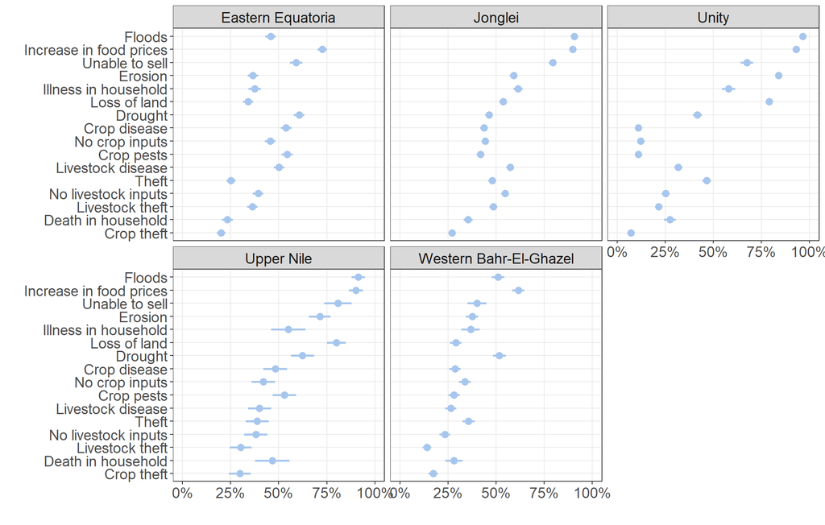

```r
ggplot(shck_state_mn_se, aes(x=mn, y=fct_reorder(shock_lab, mn))) +
  geom_errorbar(aes(xmin=lower, xmax=upper), width=0, size=1, color=light_blue) +
  geom_point(size=3, color=light_blue) +
  labs(x="",
       y="") +
  scale_x_continuous(labels=percent,
                     limits=c(0,1)) +
  facet_wrap(~state) +
  faceted
```

## 2.3 Incidence of shocks, by county

```r
shck_county_mn_se <- dat %>%
  select(state, county, shock_flood:shock_death) %>%
  group_by(state, county) %>%
  summarize(across(shock_flood:shock_death,
                   list(mn = ~mean(., na.rm=T), se = ~std.error(., na.rm=T)))) %>%
  pivot_longer(cols=3:34,
               names_to=c("discard", "var_name","measure"),
               names_sep="_",
               values_to="value") %>%
  select(-3) %>%
  pivot_wider(names_from=measure,
              values_from=value) %>%
  mutate(lower=mn-1.96*se,
         upper=mn+1.96*se) %>%
  ungroup() %>%
  mutate(shock_lab=rep(shock_labs,13)) %>%
  select(1,2, 3, 8, 4:7) %>%
  group_by(county) %>%
  mutate(county_rank=rank(-mn)) %>%
  arrange(county, desc(mn)) %>%
  ungroup()

#shck_state_mn_se

#write_csv(shck_county_mn_se, here("output/tables/shocks/shock incidence by county, unweighted.csv"))
```

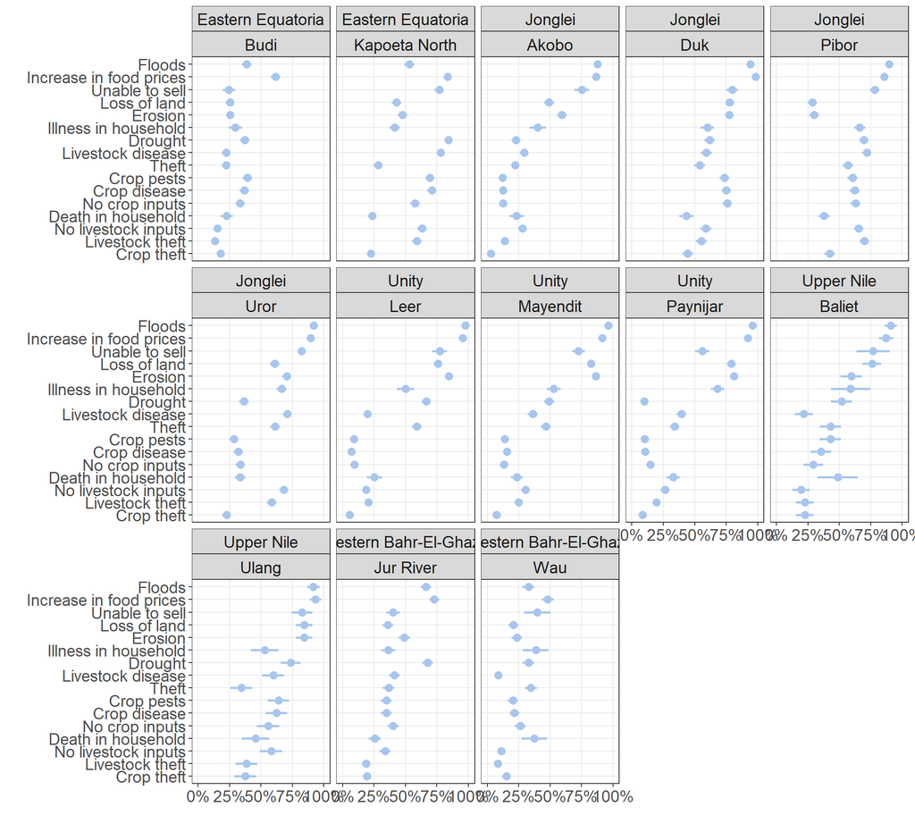

```r
ggplot(shck_county_mn_se, aes(x=mn, y=fct_reorder(shock_lab, mn))) +
  geom_errorbar(aes(xmin=lower, xmax=upper), width=0, size=1, color=light_blue) +
  geom_point(size=3, color=light_blue) +
  labs(x="",
       y="") +
  scale_x_continuous(labels=percent,
                     limits=c(0,1)) +
  facet_wrap(~state + county,
             ncol=5) +
  faceted
```

## Shock clustering

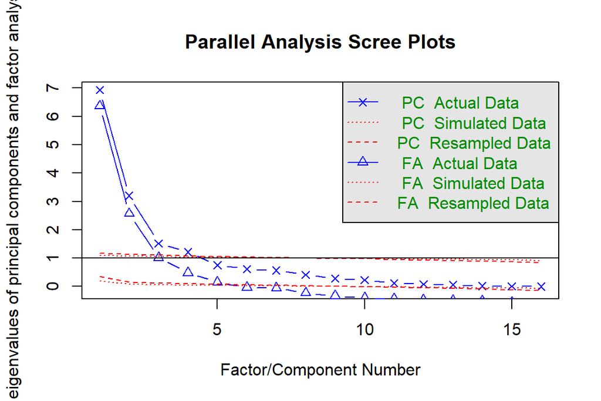

```
## Parallel analysis suggests that the number of factors =  5  and the number of components =  4
```

```r
shocks <- dat %>%
  select(shock_flood:shock_death)

fa.parallel(shocks,
            cor="tet")
```

```r
fa_shocks_5 <- fa(shocks,
                  nfactors=5,
                  cor="tet",
                  scores="tenBerge",
                  fm="ml")
```

```r
fa_shocks_5
```

```
## Factor Analysis using method =  ml
## Call: fa(r = shocks, nfactors = 5, scores = "tenBerge", fm = "ml",
##     cor = "tet")
## Standardized loadings (pattern matrix) based upon correlation matrix
##                          ML1   ML3   ML2   ML5   ML4   h2     u2 com
## shock_flood            -0.07  0.12  0.58  0.12  0.14 0.57 0.4275 1.3
## shock_drought           0.41  0.04  0.24  0.02  0.03 0.28 0.7194 1.6
## shock_erosion          -0.01  0.02  0.91 -0.05  0.05 0.85 0.1457 1.0
## shock_lostland         -0.01 -0.02  1.00  0.00  0.01 1.00 0.0050 1.0
## shock_foodprice         0.07  0.00  0.16  0.06  0.87 1.00 0.0050 1.1
## shock_theft            -0.01  0.06  0.05  0.89  0.09 0.93 0.0731 1.0
## shock_cropinputs        0.94  0.01 -0.07 -0.02  0.07 0.90 0.0990 1.0
## shock_cropdisease       0.97  0.07 -0.01 -0.10  0.02 0.98 0.0213 1.0
## shock_croppests         0.98  0.02 -0.06 -0.07  0.08 0.98 0.0240 1.0
## shock_croptheft         0.83  0.00  0.16  0.37 -0.17 1.00 0.0049 1.6
## shock_livestockinputs  -0.01  0.99  0.02  0.00 -0.06 0.94 0.0563 1.0
## shock_livestockdisease  0.02  1.01 -0.02 -0.09  0.04 1.00 0.0047 1.0
## shock_livestocktheft    0.02  0.89  0.00  0.14  0.00 0.92 0.0836 1.1
## shock_nosell            0.13  0.16  0.19  0.18  0.36 0.50 0.5000 2.8
## shock_illness          -0.06  0.10 -0.15  0.47  0.41 0.42 0.5766 2.3
## shock_death             0.04  0.08  0.12  0.43  0.06 0.32 0.6839 1.3
##
##                        ML1  ML3  ML2  ML5  ML4
## SS loadings           3.81 3.04 2.59 1.69 1.43
## Proportion Var        0.24 0.19 0.16 0.11 0.09
## Cumulative Var        0.24 0.43 0.59 0.70 0.79
## Proportion Explained  0.30 0.24 0.21 0.13 0.11
## Cumulative Proportion 0.30 0.55 0.75 0.89 1.00
##
##  With factor correlations of
##      ML1  ML3  ML2  ML5  ML4
## ML1 1.00 0.47 0.09 0.24 0.17
## ML3 0.47 1.00 0.24 0.32 0.32
## ML2 0.09 0.24 1.00 0.45 0.50
## ML5 0.24 0.32 0.45 1.00 0.27
## ML4 0.17 0.32 0.50 0.27 1.00
##
## Mean item complexity =  1.3
## Test of the hypothesis that 5 factors are sufficient.
##
## The degrees of freedom for the null model are  120  and the objective function was  41.4 with Chi Square of  271730
## The degrees of freedom for the model are 50  and the objective function was  21.3
##
## The root mean square of the residuals (RMSR) is  0.04
## The df corrected root mean square of the residuals is  0.05
##
## The harmonic number of observations is  5194 with the empirical chi square  1552  with prob <  4.3e-292
## The total number of observations was  6564  with Likelihood Chi Square =  139607  with prob <  0
##
## Tucker Lewis Index of factoring reliability =  -0.234
## RMSEA index =  0.652  and the 90 % confidence intervals are  0.649 0.655
## BIC =  139167
## Fit based upon off diagonal values = 0.99
## Measures of factor score adequacy
##                                                    ML1  ML3  ML2  ML5  ML4
## Correlation of (regression) scores with factors   1.00 1.00 1.00 0.98 1.00
## Multiple R square of scores with factors          0.99 1.00 1.00 0.97 0.99
## Minimum correlation of possible factor scores     0.99 0.99 0.99 0.93 0.99
```

ML1: crop shocks

ML3: livestock shocks

ML2: land, erosion, flood

ML4: food prices, illness

```r
fa_shocks_4 <- fa(shocks,
                  nfactors=4,
                  cor="tet",
                  scores="tenBerge",
                  fm="ml")
```

```r
fa_shocks_4
```

```
## Factor Analysis using method =  ml
## Call: fa(r = shocks, nfactors = 4, scores = "tenBerge", fm = "ml",
##     cor = "tet")
## Standardized loadings (pattern matrix) based upon correlation matrix
##                          ML2   ML3   ML1   ML4   h2     u2 com
## shock_flood            -0.06  0.72  0.11  0.06 0.61 0.3863 1.1
## shock_drought           0.44  0.21  0.00  0.12 0.31 0.6853 1.6
## shock_erosion           0.00  1.01 -0.03 -0.07 0.95 0.0525 1.0
## shock_lostland         -0.02  0.94 -0.06  0.05 0.90 0.1001 1.0
## shock_foodprice         0.11  0.58  0.17  0.04 0.49 0.5069 1.2
## shock_theft            -0.01  0.07  0.06  0.91 0.93 0.0711 1.0
## shock_cropinputs        0.95 -0.02  0.01 -0.03 0.90 0.1021 1.0
## shock_cropdisease       0.99  0.01  0.05 -0.10 0.99 0.0064 1.0
## shock_croppests         0.98 -0.03  0.03 -0.07 0.96 0.0425 1.0
## shock_croptheft         0.81  0.05 -0.04  0.38 0.94 0.0560 1.4
## shock_livestockinputs  -0.01  0.02  0.97 -0.01 0.94 0.0648 1.0
## shock_livestockdisease  0.02  0.01  1.01 -0.09 1.00 0.0047 1.0
## shock_livestocktheft    0.03 -0.04  0.88  0.19 0.93 0.0727 1.1
## shock_nosell            0.17  0.37  0.20  0.19 0.44 0.5558 2.6
## shock_illness          -0.04  0.11  0.19  0.37 0.27 0.7313 1.7
## shock_death             0.02  0.13  0.10  0.41 0.29 0.7114 1.3
##
##                        ML2  ML3  ML1  ML4
## SS loadings           3.87 3.21 3.08 1.69
## Proportion Var        0.24 0.20 0.19 0.11
## Cumulative Var        0.24 0.44 0.64 0.74
## Proportion Explained  0.33 0.27 0.26 0.14
## Cumulative Proportion 0.33 0.60 0.86 1.00
##
##  With factor correlations of
##      ML2  ML3  ML1  ML4
## ML2 1.00 0.11 0.48 0.25
## ML3 0.11 1.00 0.28 0.49
## ML1 0.48 0.28 1.00 0.33
## ML4 0.25 0.49 0.33 1.00
##
## Mean item complexity =  1.3
## Test of the hypothesis that 4 factors are sufficient.
##
## The degrees of freedom for the null model are  120  and the objective function was  41.4 with Chi Square of  271730
## The degrees of freedom for the model are 62  and the objective function was  22.6
##
## The root mean square of the residuals (RMSR) is  0.05
## The df corrected root mean square of the residuals is  0.06
##
## The harmonic number of observations is  5194 with the empirical chi square  2670  with prob <  0
## The total number of observations was  6564  with Likelihood Chi Square =  148336  with prob <  0
##
## Tucker Lewis Index of factoring reliability =  -0.057
## RMSEA index =  0.604  and the 90 % confidence intervals are  0.601 0.606
## BIC =  147791
## Fit based upon off diagonal values = 0.99
## Measures of factor score adequacy
##                                                    ML2  ML3  ML1  ML4
## Correlation of (regression) scores with factors   1.00 0.98 1.00 0.97
## Multiple R square of scores with factors          0.99 0.97 1.00 0.95
## Minimum correlation of possible factor scores     0.99 0.94 0.99 0.89
```

ML2: Crop related

ML3: Erosion, loss of land, flood, food prices

ML1: Livestock related

ML4: Theft, illness, death

Explains 74 percent of the variance. Uninterpretable Tucker Lewis fit score and unacceptable RMSEA score (.6).

## 2.4 Shock severity

## 2.5 Overall severity of shocks

Unweighted

```r
# shck_mn <- dat %>%
#   select(shock_flood:shock_death) %>%
#   summarize_all(mean, na.rm=T) %>%
#   t() %>%
#   as.data.frame() %>%
#   rownames_to_column() %>%
#   set_names(nm=c("var_name","freq")) %>%
#   left_join(shock_key) %>%
#   select(1,3,4,2) %>%
#   arrange(desc(freq))
#
# shck_mn

sev_mn_se <- dat %>%
  select(flood_severity:death_severity) %>%
  summarize(across(everything(),
                   list(mn = ~mean(.,na.rm=T), se = ~std.error(.,na.rm=T)))) %>%
  pivot_longer(cols=1:32,
               names_to=c("discard", "var_name","measure"),
               names_sep="_",
               values_to="value") %>%
#  select(-1) %>%
  pivot_wider(names_from=measure,
              values_from=value) %>%
  mutate(lower=mn-1.96*se,
         upper=mn+1.96*se,
         shock_lab=shock_labs,
         shock=1:16) %>%
  select(1,8, 7,3:6) %>%
  mutate(overall_rank = rank(-mn)) %>%
  arrange(desc(mn))

#write_csv(sev_mn_se, here("output/tables/shocks/shock severity overall, unweighted.csv"))

sev_mn_se
```

Table 2.3:

| discard | shock | shock_lab | mn | se | lower | upper | overall_rank |
| --- | --- | --- | --- | --- | --- | --- | --- |
| foodpriceinc | 5 | Increase in food prices | 5.78 | 0.0345 | 5.72 | 5.85 | 1 |
| flood | 1 | Floods | 5.4 | 0.0379 | 5.32 | 5.47 | 2 |
| erosion | 3 | Erosion | 4.06 | 0.0433 | 3.98 | 4.15 | 3 |
| lossland | 4 | Loss of land | 3.71 | 0.0436 | 3.63 | 3.8 | 4 |
| littlerain | 2 | Drought | 3.14 | 0.0416 | 3.06 | 3.22 | 5 |
| livestockdisease | 12 | Livestock disease | 2.98 | 0.0428 | 2.89 | 3.06 | 6 |
| theft | 6 | Theft | 2.77 | 0.0423 | 2.68 | 2.85 | 7 |
| livestockinput | 11 | No livestock inputs | 2.54 | 0.0409 | 2.46 | 2.62 | 8 |
| nosell | 14 | Unable to sell | 2.52 | 0.0407 | 2.44 | 2.6 | 9 |
| cropdisease | 8 | Crop disease | 2.25 | 0.0394 | 2.17 | 2.33 | 10 |
| livestocktheft | 13 | Livestock theft | 2.24 | 0.0402 | 2.16 | 2.32 | 11 |
| pest | 9 | Crop pests | 2.21 | 0.0392 | 2.13 | 2.28 | 12 |
| aginput | 7 | No crop inputs | 2.16 | 0.0384 | 2.08 | 2.23 | 13 |
| illness | 15 | Illness in household | 1.9 | 0.0377 | 1.83 | 1.98 | 14 |
| croptheft | 10 | Crop theft | 1.21 | 0.032 | 1.15 | 1.28 | 15 |
| death | 16 | Death in household | 1.19 | 0.0329 | 1.12 | 1.25 | 16 |

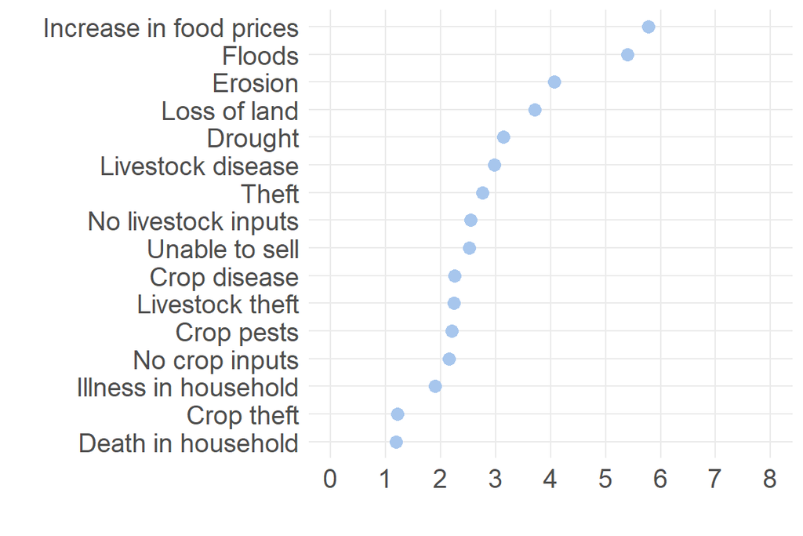

```r
ggplot(sev_mn_se, aes(x=mn, y=fct_reorder(shock_lab, mn))) +
  geom_errorbar(aes(xmin=lower, xmax=upper), width=0, size=1, color=light_blue) +
  geom_point(size=3, color=light_blue) +
  labs(x="",
       y="") +
  scale_x_continuous(limits=c(0,8),
                     breaks=0:8)
```

Weighted

Weighted

```r
sev_svy <- svyrdat %>%
  select(flood_severity:death_severity) %>%
  summarize_all(survey_mean, na.rm=T) %>%
  t() %>%
  as.data.frame() %>%
  rownames_to_column() %>%
  set_names(nm=c("var_name","freq"))

sev_mn_svy <- sev_svy %>%
  filter(row_number() %% 2 ==1) %>%
  rename(mn=freq) %>%
  mutate(shock_lab=shock_labs)

sev_se_svy <- sev_svy %>%
  filter(row_number() %% 2 == 0) %>%
  rename(se=freq) %>%
  mutate(shock_lab=shock_labs) %>%
  select(-1)

sev_mn_se_svy <- sev_mn_svy %>%
  left_join(sev_se_svy) %>%
  mutate(lower=mn-1.96*se,
         upper=mn+1.96*se) %>%
  select(1,3,2,4:6)

sev_mn_se_svy
```

Table 2.4:

| var_name | shock_lab | mn | se | lower | upper |
| --- | --- | --- | --- | --- | --- |
| flood_severity | Floods | 5.78 | 0.138 | 5.51 | 6.05 |
| little_rain_severity | Drought | 3.09 | 0.192 | 2.71 | 3.47 |
| erosion_severity | Erosion | 3.65 | 0.189 | 3.28 | 4.02 |
| loss_land_severity | Loss of land | 3.16 | 0.187 | 2.8 | 3.53 |
| food_price_inc_severity | Increase in food prices | 5.97 | 0.112 | 5.75 | 6.19 |
| theft_severity | Theft | 3.47 | 0.163 | 3.15 | 3.79 |
| ag_input_severity | No crop inputs | 2.73 | 0.13 | 2.47 | 2.98 |
| crop_disease_severity | Crop disease | 2.64 | 0.132 | 2.38 | 2.9 |
| pest_severity | Crop pests | 2.47 | 0.132 | 2.21 | 2.73 |
| crop_theft_severity | Crop theft | 1.72 | 0.123 | 1.48 | 1.96 |
| livestock_input_severity | No livestock inputs | 3.65 | 0.16 | 3.34 | 3.97 |
| livestock_disease_severity | Livestock disease | 4.04 | 0.165 | 3.72 | 4.37 |
| livestock_theft_severity | Livestock theft | 3.45 | 0.173 | 3.11 | 3.79 |
| no_sell_crop_severity | Unable to sell | 3.58 | 0.171 | 3.24 | 3.91 |
| illness_severity | Illness in household | 2.92 | 0.159 | 2.61 | 3.23 |
| death_severity | Death in household | 1.81 | 0.143 | 1.53 | 2.09 |

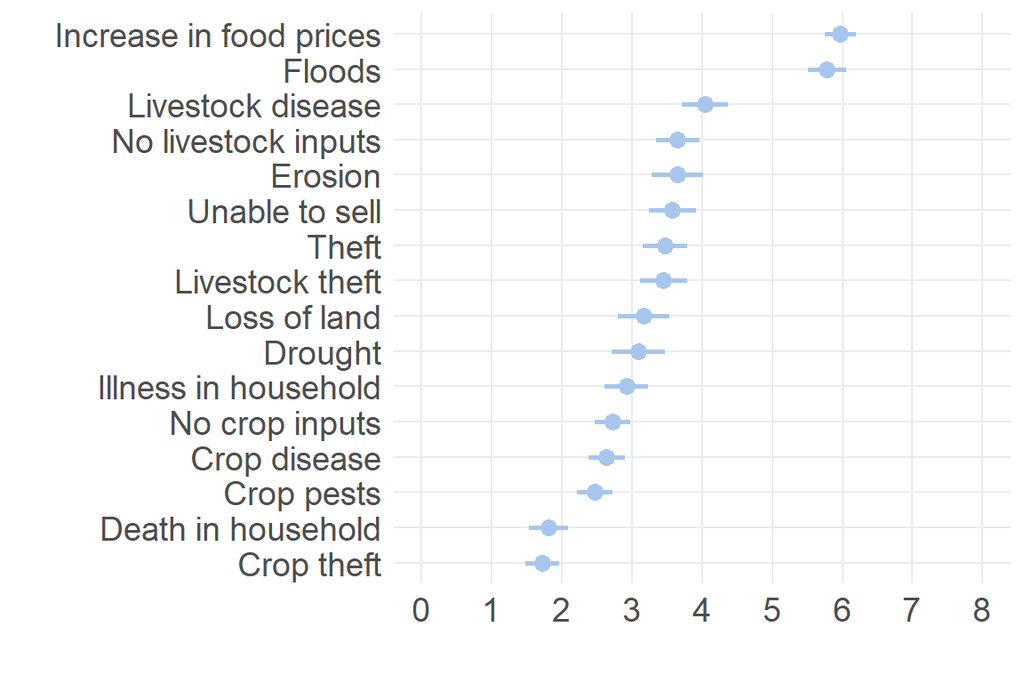

```r
ggplot(sev_mn_se_svy, aes(x=mn, y=fct_reorder(shock_lab, mn))) +
  geom_errorbar(aes(xmin=lower, xmax=upper), width=0, size=1, color=light_blue) +
  geom_point(size=3, color=light_blue) +
  labs(x="",
       y="") +
  scale_x_continuous(limits=c(0,8),
                     breaks=0:8)
```

## 2.6 Shock severity, by county

Unweighted

```r
sev_county <- dat %>%
  select(region, state, county, flood_severity:death_severity) %>%
  group_by(region, state, county) %>%
  summarize(across(flood_severity:death_severity,
                   list(mn = ~mean(., na.rm=T), se = ~std.error(., na.rm=T)))) %>%
  pivot_longer(cols=4:35,
               names_to=c("var_name","discard", "measure"),
               names_sep="_",
               values_to="value") %>%
  select(-5) %>%
  pivot_wider(names_from=measure,
              values_from=value) %>%
  mutate(lower=mn-1.96*se,
         upper=mn+1.96*se) %>%
  ungroup() %>%
  mutate(shock_lab=rep(shock_labs,13)) %>%
  select(1:4, 9, 5:8) %>%
  group_by(county) %>%
  mutate(county_rank=rank(-mn)) %>%
  arrange(county, desc(mn)) %>%
  ungroup()

sev_county
```

Table 2.5:

| region | state | county | var_name | shock_lab | mn | se | lower | upper | county_rank |
| --- | --- | --- | --- | --- | --- | --- | --- | --- | --- |
| Greater Upper Nile | Jonglei | Akobo | flood | Floods | 6.43 | 0.104 | 6.23 | 6.63 | 1 |
| Greater Upper Nile | Jonglei | Akobo | foodpriceinc | Increase in food prices | 6.42 | 0.107 | 6.21 | 6.63 | 2 |
| Greater Upper Nile | Jonglei | Akobo | erosion | Erosion | 4.29 | 0.146 | 4 | 4.57 | 3 |
| Greater Upper Nile | Jonglei | Akobo | lossland | Loss of land | 3.54 | 0.148 | 3.25 | 3.83 | 4 |
| Greater Upper Nile | Jonglei | Akobo | livestockdisease | Livestock disease | 2.14 | 0.134 | 1.87 | 2.4 | 5 |
| Greater Upper Nile | Jonglei | Akobo | livestockinput | No livestock inputs | 2.01 | 0.131 | 1.75 | 2.27 | 6 |
| Greater Upper Nile | Jonglei | Akobo | nosell | Unable to sell | 1.84 | 0.127 | 1.59 | 2.09 | 7 |
| Greater Upper Nile | Jonglei | Akobo | theft | Theft | 1.55 | 0.119 | 1.32 | 1.78 | 8 |
| Greater Upper Nile | Jonglei | Akobo | littlerain | Drought | 1.41 | 0.108 | 1.19 | 1.62 | 9 |
| Greater Upper Nile | Jonglei | Akobo | livestocktheft | Livestock theft | 1.01 | 0.103 | 0.813 | 1.22 | 10 |
| Greater Upper Nile | Jonglei | Akobo | illness | Illness in household | 0.997 | 0.101 | 0.798 | 1.2 | 11 |
| Greater Upper Nile | Jonglei | Akobo | cropdisease | Crop disease | 0.928 | 0.0985 | 0.735 | 1.12 | 12 |
| Greater Upper Nile | Jonglei | Akobo | pest | Crop pests | 0.87 | 0.0951 | 0.684 | 1.06 | 13 |
| Greater Upper Nile | Jonglei | Akobo | aginput | No crop inputs | 0.869 | 0.0938 | 0.685 | 1.05 | 14 |
| Greater Upper Nile | Jonglei | Akobo | death | Death in household | 0.581 | 0.0802 | 0.424 | 0.738 | 15 |
| Greater Upper Nile | Jonglei | Akobo | croptheft | Crop theft | 0.208 | 0.048 | 0.114 | 0.302 | 16 |
| Greater Upper Nile | Upper Nile | Baliet | flood | Floods | 6.27 | 0.202 | 5.88 | 6.67 | 1 |
| Greater Upper Nile | Upper Nile | Baliet | foodpriceinc | Increase in food prices | 5.95 | 0.222 | 5.51 | 6.38 | 2 |
| Greater Upper Nile | Upper Nile | Baliet | lossland | Loss of land | 5.03 | 0.272 | 4.5 | 5.56 | 3 |
| Greater Upper Nile | Upper Nile | Baliet | erosion | Erosion | 3.69 | 0.286 | 3.13 | 4.25 | 4 |
| Greater Upper Nile | Upper Nile | Baliet | littlerain | Drought | 3.32 | 0.297 | 2.74 | 3.9 | 5 |
| Greater Upper Nile | Upper Nile | Baliet | pest | Crop pests | 2.91 | 0.306 | 2.31 | 3.51 | 6 |
| Greater Upper Nile | Upper Nile | Baliet | theft | Theft | 2.86 | 0.301 | 2.28 | 3.45 | 7 |
| Greater Upper Nile | Upper Nile | Baliet | cropdisease | Crop disease | 2.4 | 0.296 | 1.82 | 2.98 | 8 |
| Greater Upper Nile | Upper Nile | Baliet | aginput | No crop inputs | 1.89 | 0.266 | 1.37 | 2.42 | 9 |
| Greater Upper Nile | Upper Nile | Baliet | croptheft | Crop theft | 1.48 | 0.248 | 0.996 | 1.97 | 10 |
| Greater Upper Nile | Upper Nile | Baliet | livestockdisease | Livestock disease | 1.47 | 0.249 | 0.986 | 1.96 | 11 |
| Greater Upper Nile | Upper Nile | Baliet | livestocktheft | Livestock theft | 1.43 | 0.238 | 0.963 | 1.89 | 12 |
| Greater Upper Nile | Upper Nile | Baliet | nosell | Unable to sell | 1.3 | 0.219 | 0.872 | 1.73 | 13 |
| Greater Upper Nile | Upper Nile | Baliet | livestockinput | No livestock inputs | 1.27 | 0.23 | 0.82 | 1.72 | 14 |

[output cut: 178 more lines]

```r
#write_csv(sev_county, here("output/tables/shocks/shock severity by county, unweighted.csv"))
```

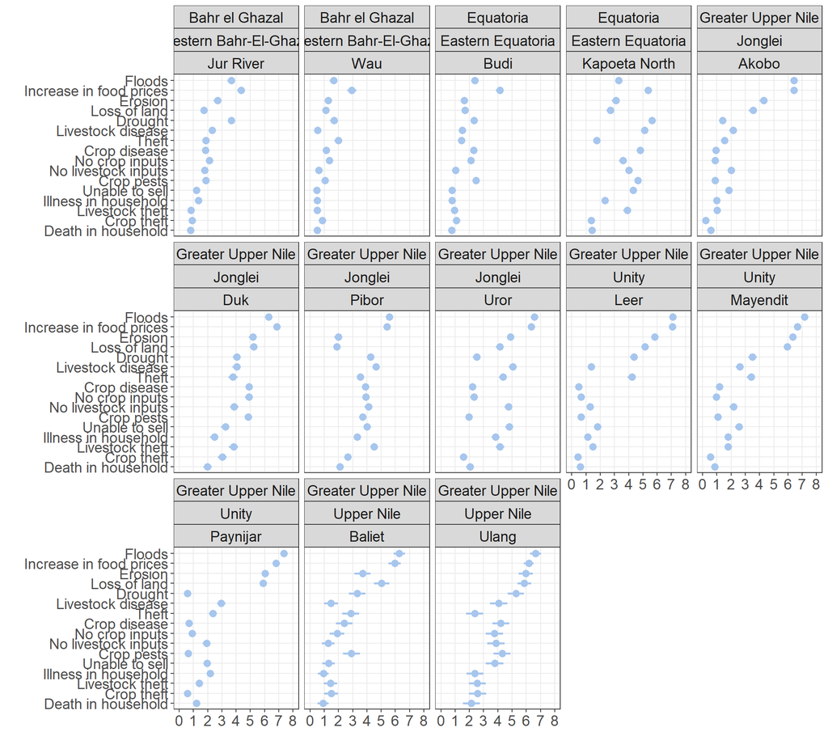

```r
ggplot(sev_county, aes(x=mn, y=fct_reorder(shock_lab, mn))) +
  geom_errorbar(aes(xmin=lower, xmax=upper), width=0, size=1, color=light_blue) +
  geom_point(size=3, color=light_blue) +
  labs(x="",
       y="") +
  scale_x_continuous(limits=c(0,8),
                     breaks=0:8) +
  facet_wrap(~region + state + county,
             ncol=5) +
  faceted
```

## 2.7 Shock clustering, weighted by severity

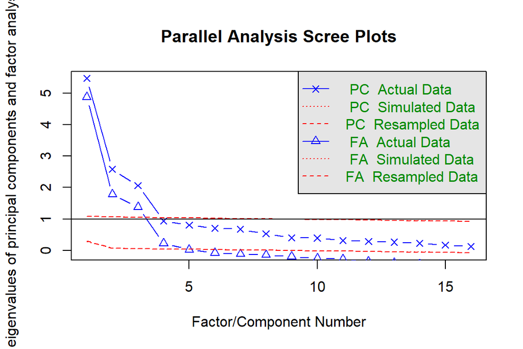

```
## Parallel analysis suggests that the number of factors =  4  and the number of components =  3
```

```r
sev <- dat %>%
  select(flood_severity:death_severity)

fa.parallel(sev)
```

```r
fa_sev_4 <- fa(sev,
                  nfactors=4,
                  scores="tenBerge",
                  fm="ml")

fa_sev_4
```

```
## Factor Analysis using method =  ml
## Call: fa(r = sev, nfactors = 4, scores = "tenBerge", fm = "ml")
## Standardized loadings (pattern matrix) based upon correlation matrix
##                             ML1   ML2   ML3   ML4   h2   u2 com
## flood_severity             0.06 -0.04  0.62 -0.03 0.39 0.61 1.0
## littlerain_severity        0.02  0.30  0.19  0.12 0.18 0.82 2.0
## erosion_severity           0.00  0.00  0.90 -0.05 0.79 0.21 1.0
## lossland_severity         -0.03 -0.01  0.85  0.04 0.72 0.28 1.0
## foodpriceinc_severity      0.09  0.05  0.48  0.00 0.27 0.73 1.1
## theft_severity             0.07  0.05  0.29  0.42 0.36 0.64 1.9
## aginput_severity           0.01  0.82 -0.01  0.02 0.69 0.31 1.0
## cropdisease_severity       0.02  0.94 -0.01 -0.06 0.88 0.12 1.0
## pest_severity              0.00  0.92 -0.02 -0.03 0.83 0.17 1.0
## croptheft_severity        -0.02  0.60  0.08  0.30 0.52 0.48 1.5
## livestockinput_severity    0.88  0.02  0.02 -0.07 0.76 0.24 1.0
## livestockdisease_severity  0.96  0.01 -0.01 -0.13 0.86 0.14 1.0
## livestocktheft_severity    0.74  0.05 -0.01  0.18 0.68 0.32 1.1
## nosell_severity            0.77  0.01  0.06  0.07 0.67 0.33 1.0
## illness_severity           0.59 -0.05 -0.02  0.31 0.52 0.48 1.5
## death_severity             0.39  0.00 -0.01  0.39 0.39 0.61 2.0
##
##                        ML1  ML2  ML3  ML4
## SS loadings           3.50 2.93 2.33 0.75
## Proportion Var        0.22 0.18 0.15 0.05
## Cumulative Var        0.22 0.40 0.55 0.59
## Proportion Explained  0.37 0.31 0.24 0.08
## Cumulative Proportion 0.37 0.68 0.92 1.00
##
##  With factor correlations of
##      ML1  ML2  ML3  ML4
## ML1 1.00 0.37 0.23 0.30
## ML2 0.37 1.00 0.08 0.14
## ML3 0.23 0.08 1.00 0.22
## ML4 0.30 0.14 0.22 1.00
##
## Mean item complexity =  1.3
## Test of the hypothesis that 4 factors are sufficient.
##
## The degrees of freedom for the null model are  120  and the objective function was  8.98 with Chi Square of  58909
## The degrees of freedom for the model are 62  and the objective function was  0.23
##
## The root mean square of the residuals (RMSR) is  0.02
## The df corrected root mean square of the residuals is  0.03
##
## The harmonic number of observations is  6558 with the empirical chi square  831  with prob <  5.9e-135
## The total number of observations was  6564  with Likelihood Chi Square =  1533  with prob <  1.6e-279
##
## Tucker Lewis Index of factoring reliability =  0.952
## RMSEA index =  0.06  and the 90 % confidence intervals are  0.058 0.063
## BIC =  988
## Fit based upon off diagonal values = 1
## Measures of factor score adequacy
##                                                    ML1  ML2  ML3  ML4
## Correlation of (regression) scores with factors   0.97 0.97 0.94 0.76
## Multiple R square of scores with factors          0.94 0.94 0.88 0.58
## Minimum correlation of possible factor scores     0.87 0.88 0.77 0.15
```

ML1: livestock, inability to sell, illness and death

ML2: crop related

ML3: erosion, loss of land, flood, food prices

ML4: theft

```r
fa_sev_3 <- fa(sev,
                  nfactors=3,
                  scores="tenBerge",
                  fm="ml")

fa_sev_3
```

```
## Factor Analysis using method =  ml
## Call: fa(r = sev, nfactors = 3, scores = "tenBerge", fm = "ml")
## Standardized loadings (pattern matrix) based upon correlation matrix
##                             ML2   ML1   ML3   h2   u2 com
## flood_severity             0.05 -0.04  0.61 0.38 0.62 1.0
## littlerain_severity        0.05  0.30  0.21 0.17 0.83 1.8
## erosion_severity          -0.01  0.00  0.87 0.76 0.24 1.0
## lossland_severity         -0.03 -0.01  0.86 0.74 0.26 1.0
## foodpriceinc_severity      0.08  0.05  0.48 0.27 0.73 1.1
## theft_severity             0.19  0.05  0.36 0.22 0.78 1.6
## aginput_severity           0.01  0.83  0.00 0.69 0.31 1.0
## cropdisease_severity       0.00  0.94 -0.02 0.88 0.12 1.0
## pest_severity             -0.02  0.92 -0.02 0.84 0.16 1.0
## croptheft_severity         0.07  0.60  0.14 0.43 0.57 1.1
## livestockinput_severity    0.87  0.00 -0.02 0.75 0.25 1.0
## livestockdisease_severity  0.91  0.01 -0.05 0.81 0.19 1.0
## livestocktheft_severity    0.80  0.04  0.00 0.67 0.33 1.0
## nosell_severity            0.81  0.00  0.06 0.68 0.32 1.0
## illness_severity           0.68 -0.06  0.03 0.45 0.55 1.0
## death_severity             0.50  0.00  0.06 0.27 0.73 1.0
##
##                        ML2  ML1  ML3
## SS loadings           3.71 2.91 2.37
## Proportion Var        0.23 0.18 0.15
## Cumulative Var        0.23 0.41 0.56
## Proportion Explained  0.41 0.32 0.26
## Cumulative Proportion 0.41 0.74 1.00
##
##  With factor correlations of
##      ML2  ML1  ML3
## ML2 1.00 0.39 0.26
## ML1 0.39 1.00 0.07
## ML3 0.26 0.07 1.00
##
## Mean item complexity =  1.1
## Test of the hypothesis that 3 factors are sufficient.
##
## The degrees of freedom for the null model are  120  and the objective function was  8.98 with Chi Square of  58909
## The degrees of freedom for the model are 75  and the objective function was  0.48
##
## The root mean square of the residuals (RMSR) is  0.04
## The df corrected root mean square of the residuals is  0.05
##
## The harmonic number of observations is  6558 with the empirical chi square  2065  with prob <  0
## The total number of observations was  6564  with Likelihood Chi Square =  3159  with prob <  0
##
## Tucker Lewis Index of factoring reliability =  0.916
## RMSEA index =  0.079  and the 90 % confidence intervals are  0.077 0.082
## BIC =  2500
## Fit based upon off diagonal values = 0.99
## Measures of factor score adequacy
##                                                    ML2  ML1  ML3
## Correlation of (regression) scores with factors   0.96 0.97 0.94
## Multiple R square of scores with factors          0.93 0.94 0.88
## Minimum correlation of possible factor scores     0.86 0.88 0.76
```

ML2: livestock, inability sell, illness and death

ML1: crop related

ML3: erosion, loss of land, flood, food prices

Explains 56 percent of the variance. Acceptable Tucker Lewis fit score (.92). RMSEA score of .08 is a little high but probably acceptable.

```r
fa_sev_3_scores <- fa_sev_3$scores %>%
  as.data.frame() %>%
  set_names(nm=c("shock_sev_livestock", "shock_sev_crops","shocks_sev_drought"))

head(fa_sev_3_scores)
```

Table 2.6:

| shock_sev_livestock | shock_sev_crops | shocks_sev_drought |
| --- | --- | --- |
| -0.539 | -0.752 | -1.13 |
| -0.917 | -0.221 | -1.24 |
| -0.926 | -0.771 | -0.318 |
| -0.927 | -0.772 | -0.333 |
| -0.926 | -0.77 | -0.183 |
| -0.506 | -0.769 | -1.45 |

```r
describe(fa_sev_3_scores)
```

Table 2.6:

| vars | n | mean | sd | median | trimmed | mad | min | max | range | skew | kurtosis | se |
| --- | --- | --- | --- | --- | --- | --- | --- | --- | --- | --- | --- | --- |
| 1 | 6.52e+03 | 0.000104 | 1 | -0.675 | -0.102 | 0.367 | -0.939 | 2.01 | 2.95 | 0.551 | -1.33 | 0.0124 |
| 2 | 6.52e+03 | -0.000392 | 1 | -0.705 | -0.133 | 0.0965 | -0.793 | 2.08 | 2.87 | 0.816 | -1.07 | 0.0124 |
| 3 | 6.52e+03 | -0.000326 | 1 | 0.128 | 0.0128 | 1.48 | -1.63 | 1.48 | 3.1 | -0.111 | -1.59 | 0.0124 |

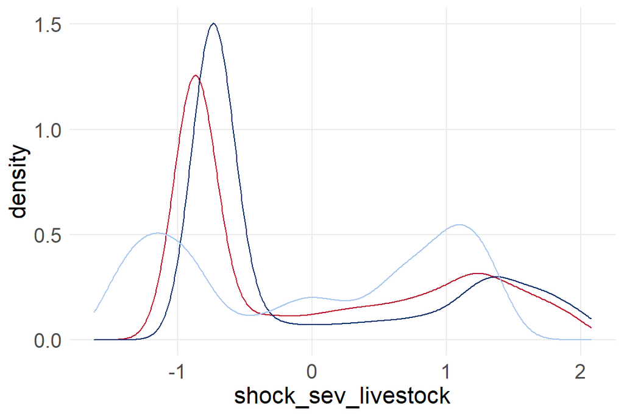

```r
dat <- dat %>%
  mutate(shock_sev_livestock=fa_sev_3_scores$shock_sev_livestock,
         shock_sev_crops = fa_sev_3_scores$shock_sev_crops,
         shock_sev_drought=fa_sev_3_scores$shocks_sev_drought)

ggplot(dat) +
  geom_density(aes(shock_sev_livestock), color=usaid_red) +
  geom_density(aes(shock_sev_crops), color=usaid_blue) +
  geom_density(aes(shock_sev_drought), color=light_blue)
```

## 2.8 Shock exposure

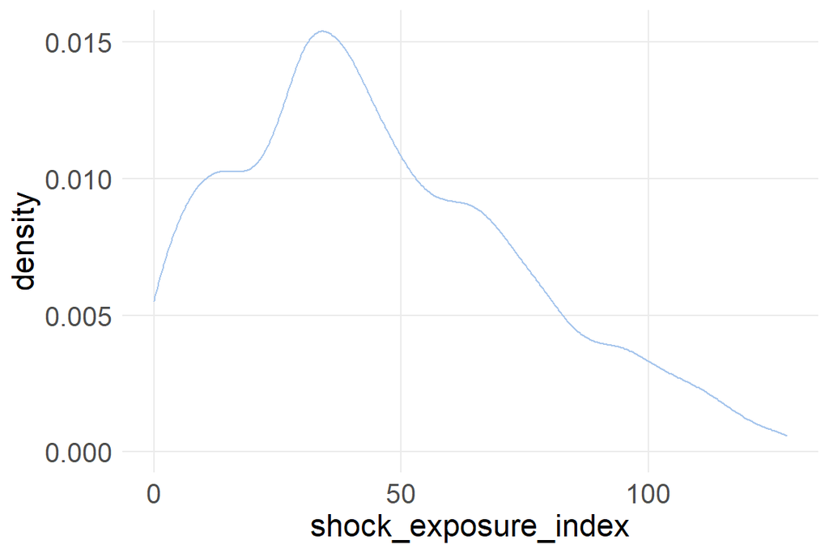

```r
ggplot(dat, aes(shock_exposure_index)) +
  geom_density(color=light_blue)
```

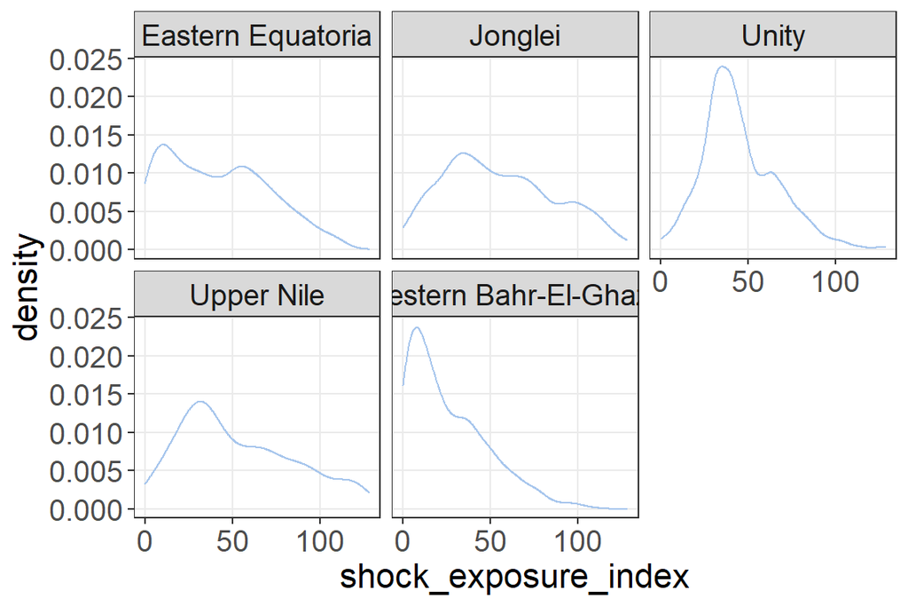

```r
ggplot(dat, aes(shock_exposure_index)) +
  #geom_bar() +
  geom_density(color=light_blue) +
  facet_wrap(~state) +
  faceted
```

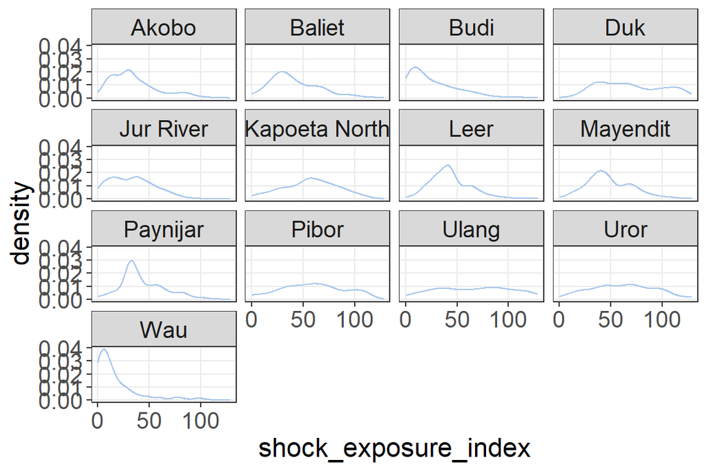

```r
ggplot(dat, aes(shock_exposure_index)) +
  #geom_bar() +
  geom_density(color=light_blue) +
  facet_wrap(~county) +
  faceted
```

```r
expos <- dat %>%
  group_by(state, county) %>%
  summarize(exposure=mean(shock_exposure_index, na.rm=T),
            se=std.error(shock_exposure_index, na.rm=T)) %>%
  mutate(lower=exposure-1.96*se,
         upper=exposure+1.96*se)

expos
```

| state | county | exposure | se | lower | upper |
| --- | --- | --- | --- | --- | --- |
| Eastern Equatoria | Budi | 26.8 | 0.967 | 24.9 | 28.7 |
| Eastern Equatoria | Kapoeta North | 57.1 | 1.053 | 55.0 | 59.1 |
| Jonglei | Akobo | 35.0 | 0.928 | 33.2 | 36.8 |
| Jonglei | Duk | 68.0 | 1.351 | 65.3 | 70.6 |
| Jonglei | Pibor | 59.1 | 1.282 | 56.6 | 61.6 |
| Jonglei | Uror | 61.5 | 1.254 | 59.0 | 63.9 |
| Unity | Leer | 43.4 | 0.818 | 41.8 | 45.0 |
| Unity | Mayendit | 48.5 | 0.918 | 46.7 | 50.3 |
| Unity | Paynijar | 43.1 | 0.875 | 41.4 | 44.8 |
| Upper Nile | Baliet | 41.3 | 2.106 | 37.1 | 45.4 |
| Upper Nile | Ulang | 65.9 | 3.254 | 59.5 | 72.3 |
| Western Bahr-El-Ghazel | Jur River | 32.9 | 0.939 | 31.1 | 34.8 |
| Western Bahr-El-Ghazel | Wau | 17.8 | 1.074 | 15.7 | 19.9 |

Unweighted

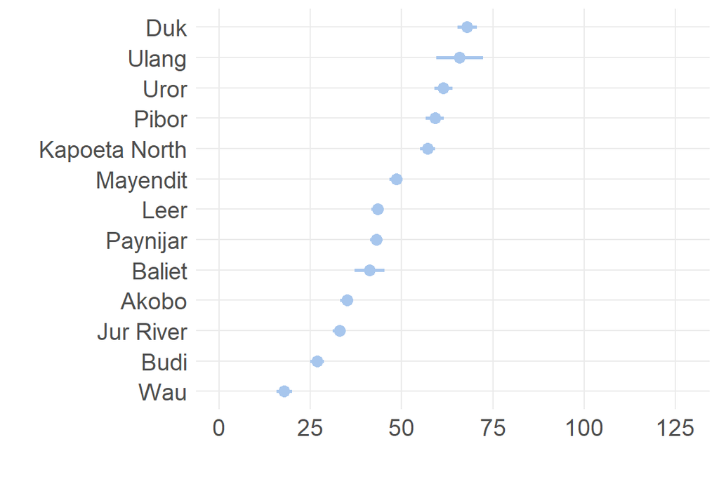

```r
ggplot(expos, aes(x=exposure, y=fct_reorder(county, exposure))) +
  geom_errorbar(aes(xmin=lower, xmax=upper), width=0, size=1, color=light_blue) +
  geom_point(size=3, color=light_blue) +
  labs(x="",
       y="") +
  scale_x_continuous(limits=c(0,128),
                     breaks=seq(0,125,25))
```

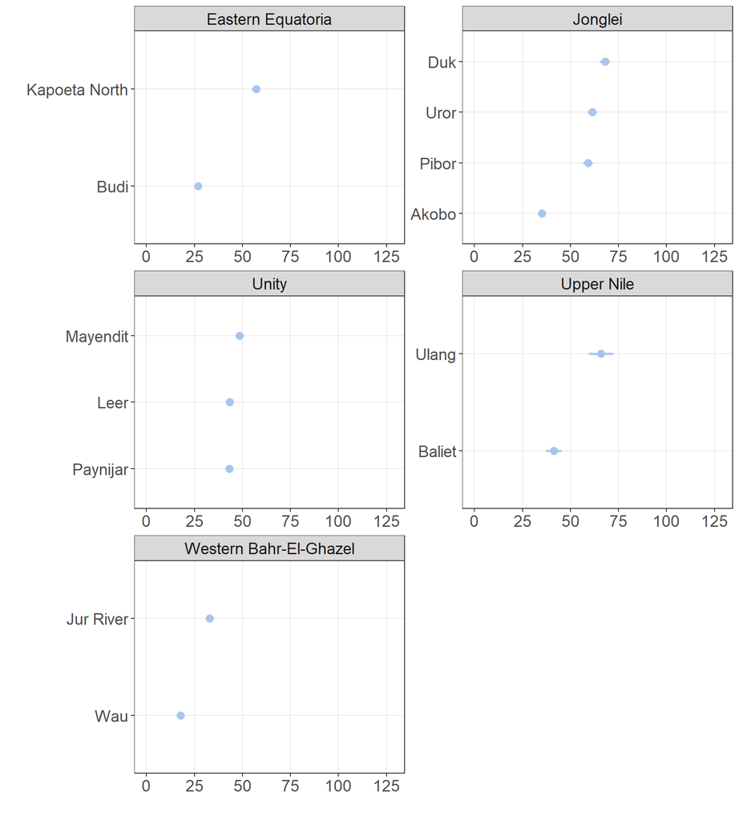

```r
ggplot(expos, aes(x=exposure, y=fct_reorder(county, exposure))) +
  geom_errorbar(aes(xmin=lower, xmax=upper), width=0, size=1, color=light_blue) +
  geom_point(size=3, color=light_blue) +
  labs(x="",
       y="") +
  scale_x_continuous(limits=c(0,128),
                     breaks=seq(0,125,25)) +
  facet_wrap(~state,
             scales="free",
             ncol=2) +
  faceted
```

Weighted

```r
expos_wt <- svyrdat %>%
  group_by(county) %>%
  summarize(exposure=survey_mean(shock_exposure_index, na.rm=T)) %>%
  mutate(lower=exposure-1.96*exposure_se,
         upper=exposure+1.96*exposure_se)

expos_wt
```

Table 2.7:

| county | exposure | exposure_se | lower | upper |
| --- | --- | --- | --- | --- |
| Akobo | 34.7 | 2.47 | 29.9 | 39.6 |
| Budi | 26.1 | 3.11 | 20 | 32.2 |
| Duk | 75 | 6.02 | 63.2 | 86.8 |
| Leer | 43 | 1.29 | 40.5 | 45.5 |
| Pibor | 59.9 | 1.83 | 56.3 | 63.5 |
| Uror | 61.2 | 3.49 | 54.4 | 68 |

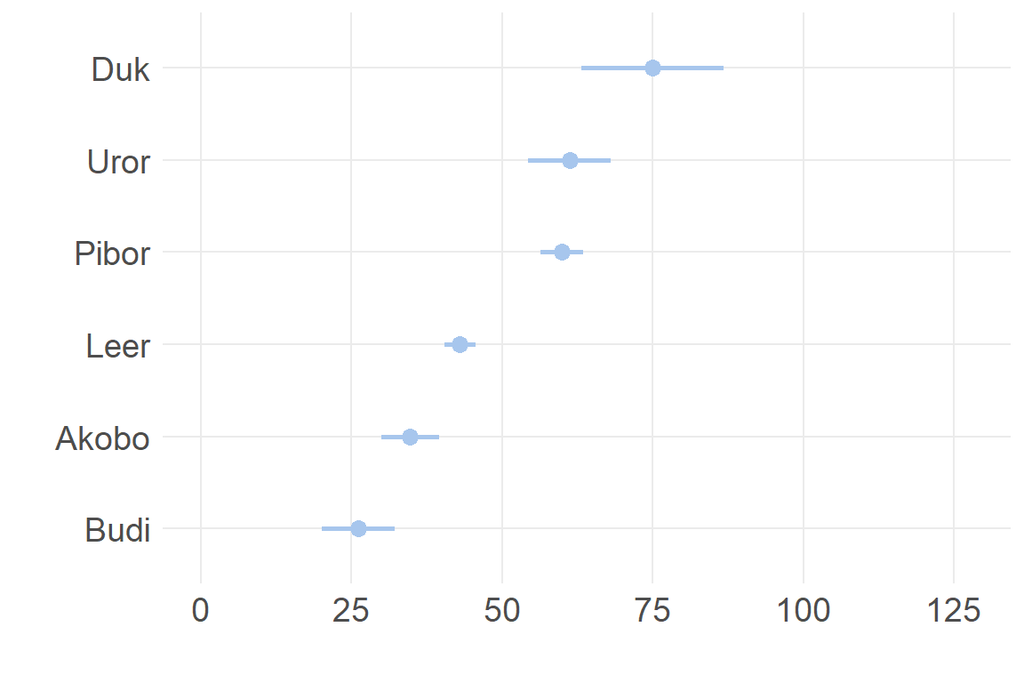

```r
ggplot(expos_wt, aes(x=exposure, y=fct_reorder(county, exposure))) +
  geom_errorbar(aes(xmin=lower, xmax=upper), width=0, size=1, color=light_blue) +
  geom_point(size=3, color=light_blue) +
  labs(x="",
       y="") +
  scale_x_continuous(limits=c(0,128),
                     breaks=seq(0,125,25))
```

# 3 Ability to recover

```r
frq(dat$ability_recover)
```

```
##
## Ability to Recover Raw (x) <numeric>
## # total N=6564  valid N=6295  mean=3.74  sd=1.43
##
## Value |    N | Raw % | Valid % | Cum. %
## ---------------------------------------
##     2 | 1787 | 27.22 |   28.39 |  28.39
##     3 | 1005 | 15.31 |   15.97 |  44.35
##     4 | 1705 | 25.98 |   27.08 |  71.44
##     5 |  683 | 10.41 |   10.85 |  82.29
##     6 | 1115 | 16.99 |   17.71 | 100.00
##  <NA> |  269 |  4.10 |    <NA> |   <NA>
```

```r
rec_county <- dat %>%
  group_by(region, state, county) %>%
  summarize(rec = mean(ability_recover, na.rm=T),
            se = std.error(ability_recover, na.rm=T)) %>%
  arrange(desc(rec))  %>%
  mutate(lower=rec-1.96*se,
         upper=rec+1.96*se)

rec_county
```

| region | state | county | rec | se | lower | upper |
| --- | --- | --- | --- | --- | --- | --- |
| Greater Upper Nile | Jonglei | Pibor | 5.16 | 0.053 | 5.06 | 5.27 |
| Bahr el Ghazal | Western Bahr-El-Ghazel | Jur River | 4.12 | 0.063 | 4.00 | 4.24 |
| Bahr el Ghazal | Western Bahr-El-Ghazel | Wau | 3.97 | 0.074 | 3.83 | 4.12 |
| Equatoria | Eastern Equatoria | Kapoeta North | 3.93 | 0.037 | 3.86 | 4.00 |
| Greater Upper Nile | Jonglei | Duk | 3.87 | 0.066 | 3.74 | 4.00 |
| Greater Upper Nile | Upper Nile | Baliet | 3.86 | 0.138 | 3.59 | 4.13 |
| Greater Upper Nile | Unity | Leer | 3.85 | 0.057 | 3.74 | 3.96 |
| Equatoria | Eastern Equatoria | Budi | 3.81 | 0.060 | 3.69 | 3.93 |
| Greater Upper Nile | Jonglei | Akobo | 3.45 | 0.057 | 3.34 | 3.56 |
| Greater Upper Nile | Unity | Paynijar | 3.27 | 0.053 | 3.16 | 3.37 |
| Greater Upper Nile | Jonglei | Uror | 3.15 | 0.051 | 3.05 | 3.25 |
| Greater Upper Nile | Unity | Mayendit | 3.00 | 0.052 | 2.90 | 3.10 |
| Greater Upper Nile | Upper Nile | Ulang | 2.91 | 0.084 | 2.74 | 3.07 |

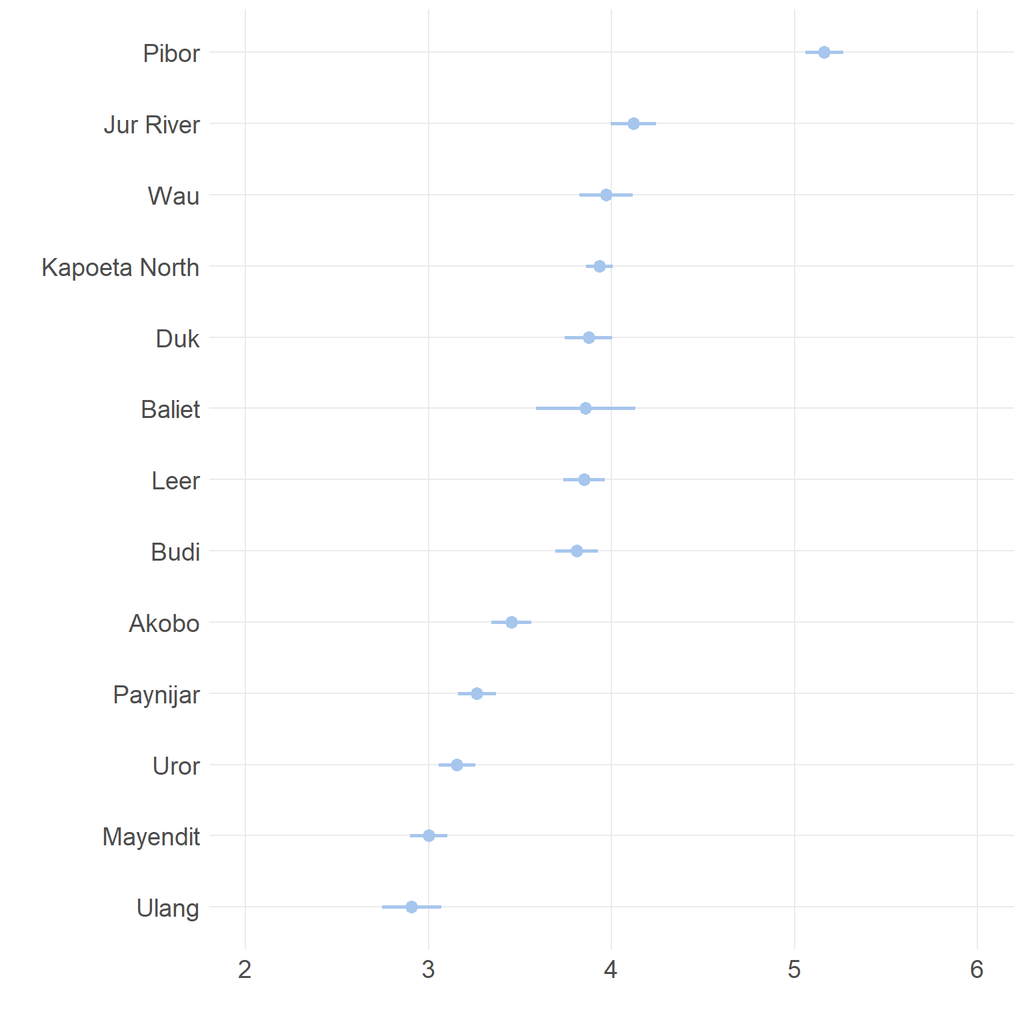

```r
ggplot(rec_county, aes(x=rec, y=fct_reorder(county, rec))) +
  geom_errorbar(aes(xmin=lower, xmax=upper), width=0, size=1, color=light_blue) +
  geom_point(size=3, color=light_blue) +
  labs(x="",
       y="") +
  scale_x_continuous(limits=c(2,6),
                     breaks=2:6)
```

```r
+
  facet_wrap(~region + state,
             ncol=5,
             scales="free") +
  faceted
```

[output not shown]

```r
rec_lang <- dat %>%
  group_by(q_211) %>%
  summarize(rec = mean(ability_recover, na.rm=T),
            se = std.error(ability_recover, na.rm=T)) %>%
  arrange(desc(rec))  %>%
  mutate(lower=rec-1.96*se,
         upper=rec+1.96*se)

rec_lang
```

Table 3.1:

| q_211 | rec | se | lower | upper |
| --- | --- | --- | --- | --- |
|  | 5.76 | 0.0952 | 5.58 | 5.95 |
| 8 | 5.18 | 0.0543 | 5.07 | 5.28 |
| 5 | 4.83 | 0.283 | 4.28 | 5.39 |
| 6 | 4.73 | 0.3 | 4.14 | 5.32 |
| 13 | 4.18 | 0.136 | 3.91 | 4.45 |
| 4 | 4.07 | 0.0537 | 3.96 | 4.17 |
| 14 | 3.93 | 0.0366 | 3.86 | 4.01 |
| 10 | 3.91 | 0.0711 | 3.77 | 4.05 |
| 2 | 3.66 | 0.146 | 3.37 | 3.94 |
| 3 | 3.65 | 0.0593 | 3.54 | 3.77 |
| 9 | 3.35 | 0.0237 | 3.3 | 3.39 |
| 11 | 3.17 | 0.316 | 2.55 | 3.79 |

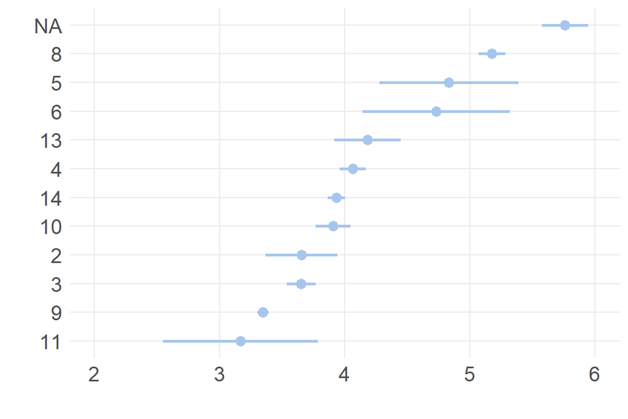

```r
ggplot(rec_lang, aes(x=rec, y=reorder(as.numeric(q_211), rec))) +
  geom_errorbar(aes(xmin=lower, xmax=upper), width=0, size=1, color=light_blue) +
  geom_point(size=3, color=light_blue) +
  labs(x="",
       y="") +
  scale_x_continuous(limits=c(2,6),
                     breaks=2:6)
```

```r
+
  facet_wrap(~region + state,
             ncol=5,
             scales="free") +
  faceted
```

[output not shown]

## 3.1 ARSSI

Exploration of indicator table presentation

```r
frq(dat$arssi)
```

[output not shown]

[output cut: 552 more lines]

```
##  6.13 |   1 |  0.02 |    0.02 |  99.46
##  6.13 |   3 |  0.05 |    0.05 |  99.50
##  6.13 |   1 |  0.02 |    0.02 |  99.52
##  6.14 |   9 |  0.14 |    0.14 |  99.66
##  6.14 |   5 |  0.08 |    0.08 |  99.74
##  6.14 |   3 |  0.05 |    0.05 |  99.79
##  6.14 |   1 |  0.02 |    0.02 |  99.81
##  6.14 |   2 |  0.03 |    0.03 |  99.84
##  6.15 |   3 |  0.05 |    0.05 |  99.89
##  6.15 |   1 |  0.02 |    0.02 |  99.90
##  6.15 |   1 |  0.02 |    0.02 |  99.92
##  6.15 |   3 |  0.05 |    0.05 |  99.97
##  6.16 |   1 |  0.02 |    0.02 |  99.98
##  6.16 |   1 |  0.02 |    0.02 | 100.00
##  <NA> | 311 |  4.74 |    <NA> |   <NA>
```

```r
arssi_mn <- svyrdat %>%
  group_by() %>%
  summarize(Value=survey_mean(arssi, na.rm=T)) %>%
  mutate(Lower=Value-Value_se*1.96,
         Upper=Value+Value_se*1.96,
         Disaggregate="Overall",
         `Disaggregate type`="Overall") %>%
  select(5,6,1,3:4)

arssi_mn
```

Table 3.2:

| Disaggregate | Disaggregate type | Value | Lower | Upper |
| --- | --- | --- | --- | --- |
| Overall | Overall | 4.02 | 3.87 | 4.18 |

```r
arssi_reg <- svyrdat %>%
  group_by(`Disaggregate type`=region) %>%
  summarize(Value=survey_mean(arssi, na.rm=T)) %>%
  mutate(Lower=Value-Value_se*1.96,
         Upper=Value+Value_se*1.96,
         Disaggregate="Region") %>%
  select(6,1,2,4:5)

arssi_reg
```

Table 3.3:

| Disaggregate | Disaggregate type | Value | Lower | Upper |
| --- | --- | --- | --- | --- |
| Region | Equatoria | 3.9 | 3.47 | 4.33 |
| Region | Greater Upper Nile | 4.04 | 3.87 | 4.2 |

```r
arssi_state <- svyrdat %>%
  group_by(`Disaggregate type`=state) %>%
  summarize(Value=survey_mean(arssi, na.rm=T)) %>%
  mutate(Lower=Value-Value_se*1.96,
         Upper=Value+Value_se*1.96,
         Disaggregate="State") %>%
  select(6, 1, 2, 4:5)

arssi_state
```

Table 3.4:

| Disaggregate | Disaggregate type | Value | Lower | Upper |
| --- | --- | --- | --- | --- |
| State | Eastern Equatoria | 3.9 | 3.47 | 4.33 |
| State | Jonglei | 4.05 | 3.88 | 4.23 |
| State | Unity | 3.77 | 3.55 | 3.99 |

```r
arssi_county <- svyrdat %>%
  group_by(`Disaggregate type`=county) %>%
#  group_by(Region=region, State=state, County=county) %>%
  summarize(Value=survey_mean(arssi, na.rm=T)) %>%
  mutate(Lower=Value-Value_se*1.96,
         Upper=Value+Value_se*1.96,
         Disaggregate="County") %>%
  select(6,1,2,4:5)

arssi_county
```

Table 3.5:

| Disaggregate | Disaggregate type | Value | Lower | Upper |
| --- | --- | --- | --- | --- |
| County | Akobo | 3.47 | 3.19 | 3.75 |
| County | Budi | 3.9 | 3.47 | 4.33 |
| County | Duk | 4.16 | 3.62 | 4.71 |
| County | Leer | 3.77 | 3.55 | 3.99 |
| County | Pibor | 5.19 | 4.96 | 5.42 |
| County | Uror | 3.18 | 2.95 | 3.4 |

```r
ind_arssi <- do.call(rbind, list(arssi_mn,
                                 arssi_reg,
                                 arssi_state,
                                 arssi_county))

#ind_arssi

#write_csv(ind_arssi, here("output/tables/shocks/indicator - arssi.csv"))

ind_arssi_gt <- ind_arssi %>%
  gt() %>%
  tab_source_note(source_note="Ability to recover from shocks and stresses")

ind_arssi_gt
```

| Disaggregate | Disaggregate type | Value | Lower | Upper |
| --- | --- | --- | --- | --- |
| Overall | Overall | 4.02 | 3.87 | 4.18 |
| Region | Equatoria | 3.90 | 3.47 | 4.33 |
| Region | Greater Upper Nile | 4.04 | 3.87 | 4.20 |
| State | Eastern Equatoria | 3.90 | 3.47 | 4.33 |
| State | Jonglei | 4.05 | 3.88 | 4.23 |
| State | Unity | 3.77 | 3.55 | 3.99 |
| County | Akobo | 3.47 | 3.19 | 3.75 |
| County | Budi | 3.90 | 3.47 | 4.33 |
| County | Duk | 4.16 | 3.62 | 4.71 |
| County | Leer | 3.77 | 3.55 | 3.99 |
| County | Pibor | 5.19 | 4.96 | 5.42 |
| County | Uror | 3.18 | 2.95 | 3.40 |

Ability to recover from shocks and stresses

```r
#gtsave(ind_arssi_gt, here("output/tables/shocks/indicator 26 - arssi.rtf"))
```

# 4 Food security and shocks

```r
l1 <- lm(fies_raw ~ shock_exposure_index,
         data=dat)

summary(l1)
```

```
##
## Call:
## lm(formula = fies_raw ~ shock_exposure_index, data = dat)
##
## Residuals:
##    Min     1Q Median     3Q    Max
## -8.285 -0.025  0.415  0.674  1.089
##
## Coefficients:
##                      Estimate Std. Error t value Pr(>|t|)
## (Intercept)           6.91098    0.03373   204.9   <2e-16 ***
## shock_exposure_index  0.01296    0.00062    20.9   <2e-16 ***
## ---
## Signif. codes:  0 '***' 0.001 '**' 0.01 '*' 0.05 '.' 0.1 ' ' 1
##
## Residual standard error: 1.44 on 6403 degrees of freedom
##   (159 observations deleted due to missingness)
## Multiple R-squared:  0.0638, Adjusted R-squared:  0.0637
## F-statistic:  437 on 1 and 6403 DF,  p-value: <2e-16
```

```r
l2 <- lm(fies_raw ~ shock_sev_livestock + shock_sev_crops + shock_sev_drought,
         data=dat)

summary(l2)
```

```
##
## Call:
## lm(formula = fies_raw ~ shock_sev_livestock + shock_sev_crops +
##     shock_sev_drought, data = dat)
##
## Residuals:
##    Min     1Q Median     3Q    Max
## -8.294 -0.027  0.304  0.687  1.163
##
## Coefficients:
##                     Estimate Std. Error t value     Pr(>|t|)
## (Intercept)           7.5037     0.0179  419.76      < 2e-16 ***
## shock_sev_livestock   0.1085     0.0200    5.43 0.0000000571 ***
## shock_sev_crops       0.1114     0.0194    5.75 0.0000000091 ***
## shock_sev_drought     0.3276     0.0186   17.66      < 2e-16 ***
## ---
## Signif. codes:  0 '***' 0.001 '**' 0.01 '*' 0.05 '.' 0.1 ' ' 1
##
## Residual standard error: 1.43 on 6401 degrees of freedom
##   (159 observations deleted due to missingness)
## Multiple R-squared:  0.074,  Adjusted R-squared:  0.0736
## F-statistic:  170 on 3 and 6401 DF,  p-value: <2e-16
```

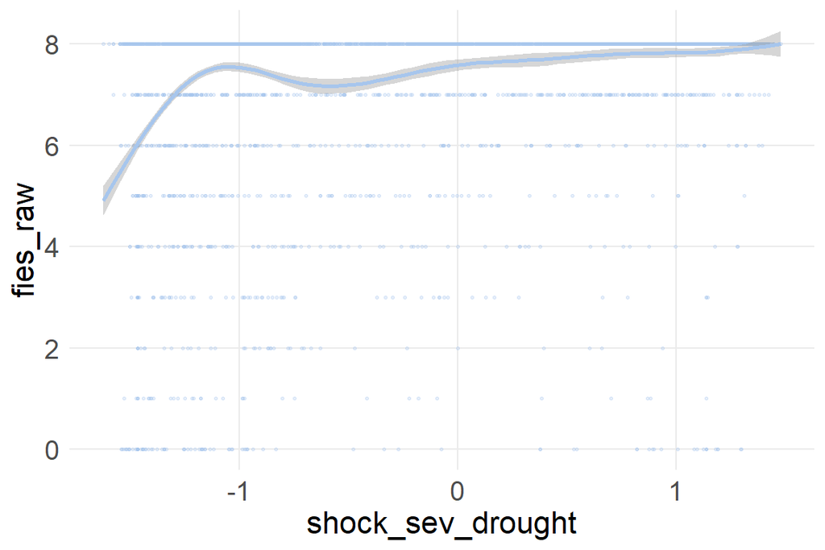

```r
ggplot(dat, aes(x=shock_sev_drought, y=fies_raw)) +
  geom_point(size=.5, alpha=.3, color=light_blue) +
  stat_smooth(color=light_blue)
```

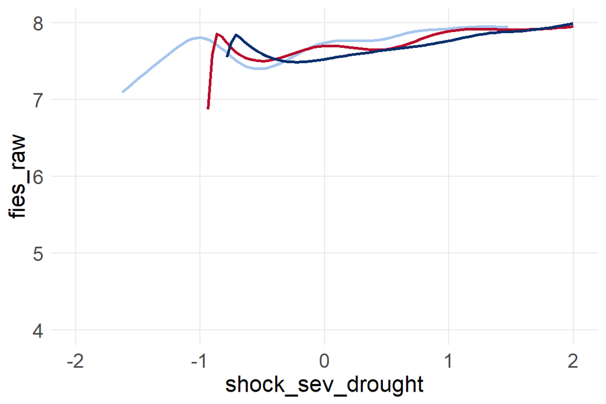

```r
ggplot(dat, aes(x=shock_sev_drought, y=fies_raw)) +
  stat_smooth(color=light_blue, se=F) +
  stat_smooth(aes(shock_sev_livestock), color=usaid_red, se=F) +
  stat_smooth(aes(shock_sev_crops), color=usaid_blue, se=F) +
  scale_x_continuous(limits=c(-2,2)) +
  scale_y_continuous(limits=c(4,8),
                     breaks=1:8)
```

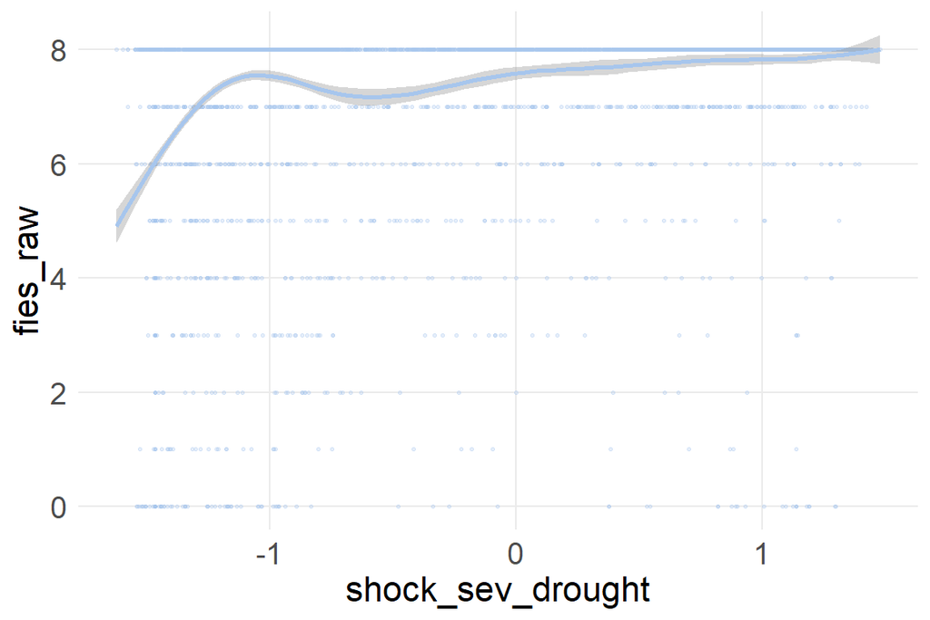

```r
ggplot(dat, aes(x=shock_sev_drought, y=fies_raw)) +
  geom_point(size=.5, alpha=.3, color=light_blue) +
  stat_smooth(color=light_blue)
```

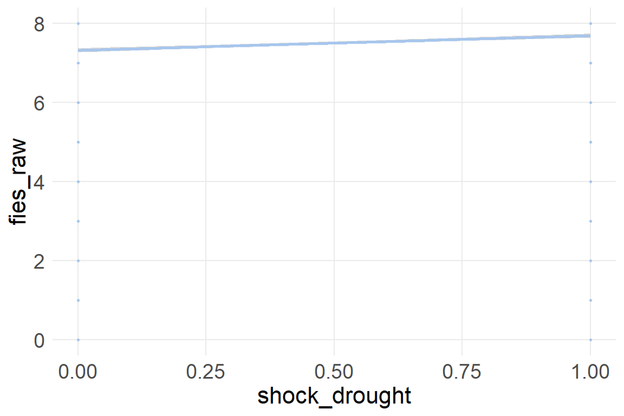

```r
ggplot(dat, aes(x=shock_drought, y=fies_raw)) +
  geom_point(size=.5, alpha=.3, color=light_blue) +
  stat_smooth(color=light_blue,
              method="lm")
```